# SemesterOppgave Sok-2005-22V

Kandidatnr. 34 & 36

2 6 2022

### **OPPG 1**

Etter å ha lastet ned datasettene, lastes de opp fra filen de ble lagt i ved enkel bruk av *dir(path="")* der alle _"*.csv"_ filer blir valgt.

```r
Sandwich_files <- dir(path = "~/sok_1005_v22/SemesterOppg1005/Datasettene/SandwichReport",pattern="*.csv")
Sandwich_files
```

Ved bruk av *readr::read_csv* leses csv filene inn som datasett med ønsket navn.

```r
Attributes = read_csv(Sandwich_files[1])
Crime = read_csv(Sandwich_files[2])
```

```r
Demographic = read_csv(Sandwich_files[3])
Employment = read_csv(Sandwich_files[4])
Sales = read_csv(Sandwich_files[5])
Weather = read_csv(Sandwich_files[6])
```

Gjør klar noen kolonner som deler nesten samme navn, og samme verdier i ett eller fler av datasettene. Lager dato av Year, Month, Day kolonnene med bruk av *lubridate::make_date* Det gjøres fordi den senere skal joines med *Weekly_Weather*.

```r
Weekly_Sales_Stores<-Sales %>%
  rename("Store_Num" = "Store_num") %>%
  mutate(Date = make_date(Year,Month,Day)) %>%
  relocate(Date)
# Sjekker class for å forsikre at den er "Date"
class(Weekly_Sales_Stores$Date)

head(Weekly_Sales_Stores)

# Her lages Date i datasettet Weekly_Weather.I tillegg gis nytt navn til
# "Weather_Station" for joining senere.
Weekly_Weather <- Weather %>%
  rename(Store_Weather_Station = Weather_Station) %>%
  mutate(Date = as.Date(Weather_Date, format = "%d/%m/%Y")) %>%
  relocate(Date)

class(Weekly_Weather$Date)

head(Weekly_Weather)
```

Setter sammen alle datasettene ved bruk av *full_join()*, for oss var dette løsnigen. Begynte med å joine datasettene som delte *“County_Name”*. Deretter gjor vi rename fra *“County_Name”* til *“Store_County”* for å joine *Attributes*.

Så endret vi navnet *“Store_num”* til *“Store_Num”* for å joine Weekly_sales_Stores. Da var det bare å joine *Weekly_Weather*, det gjøres ved *“Date”* og *“Store_Weather_Station”* Til slutt flyttet vi på noen kolonner vi ønsket fremst i dat store datasettet.

```r
Sandwich_df <- Crime %>%
  full_join(Demographic, by = "County_Name") %>%
  full_join(Employment, by = "County_Name") %>%
  rename(Store_County = County_Name) %>%
  full_join(Attributes, by = "Store_County")  %>%
  full_join(Weekly_Sales_Stores, by = c("Store_Num")) %>%
  full_join(Weekly_Weather, by = c("Date", "Store_Weather_Station")) %>%
  relocate(Date, Store_Num, Store_County) %>%
  group_by(Store_County, Store_Num, Date) %>%
  arrange(desc(Date))

head(Sandwich_df)
```

### **OPPG 2**

Vi tenkte at det ville være relevant i en ukentlig rapport å se prosentvise endringer. At vi ville gjøre nettopp det, ga oss muligheten til å finne prosent endring i profit fra forrige uke, altså uken før, og nåværende uke, samt finne den prosentvise endringen for samme uke forrige måned. Disse var ønskelig å illustrere i hvert sitt plot.

Prosentvise endringer er greit nok det, men vi ville gjøre noe annet også. Da valgte vi, med tanke på at vi var *ACME Analytics*, at vi ville vise konsernledelsen at dersom det er ønskelig for dem, kan de be om å se hvilke varer de har lyst å se utviklingen til, og hvor mye som selges av de. Mer om det etterhvert.

```r
# Velger et enkelt utsalgsted. Dette var helt tilfeldig.
Utsalgsted_24 <- Sandwich_df %>%
  filter(Store_Num == 24)

# For å begynne den ukentlig rapporten, hentes siste uke fra Sandwich_df
# med ønskede kolonner, select(), filter(), group_by(Date).
Last_Week_Profit <- Utsalgsted_24 %>%
  ungroup() %>%
  select(Date,INV_NUMBER, Description, Profit) %>%
  filter(Date == as.Date("2013-03-24")) %>%
  group_by(Date)
# Her summeres ukentlig profit fra alle vare solgt, ny kolonne "Tot_Profit"
Last_Week_Profit$Tot_Profit<- sum(Last_Week_Profit$Profit)
```

```r
# For å se prosentvis endring fra uken før, begynte vi med å hente
# ut tilsvarende data ønsket som i nåværende uke.
The_Week_Before_Profit <- Utsalgsted_24 %>%
  ungroup() %>%
  select(Date,INV_NUMBER, Description, Profit) %>%
  filter(Date == as.Date("2013-03-17")) %>%
  group_by(Date)
# Samme med denne uken summeres ukentlig profit fra alle vare solgt, ny kolonne "Tot_Profit"
The_Week_Before_Profit$Tot_Profit <- sum(The_Week_Before_Profit$Profit)#

# Fordi de deler samme navn i kollonnene, binder vi disse sammen med base::rbind
Rapport_Weekly_Change <- rbind(Last_Week_Profit, The_Week_Before_Profit)

# Så fjerner vi de duplikerte verdiene i settet, først å frems med tanke på plot.
Rapport_Weekly_Change <- Rapport_Weekly_Change[!duplicated(Rapport_Weekly_Change$Tot_Profit),]

# Lager bruker-definert function som gjør at vi kan regne ut å få endringen i prosent.
percent <- function(x, digits = 2, format = "f", ...) {
  paste0(formatC(x * 100, format = format, digits = digits, ...), "%")
}
# Da var regnestykket enkelt, forrige uke - uken nå / forrige uke * 100
Percent_Change = (Rapport_Weekly_Change$Tot_Profit[2]-Rapport_Weekly_Change$Tot_Profit[1])/Rapport_Weekly_Change$Tot_Profit[2]*-1
# Her la vi med tanke på ønsket plot, forrige ukes profit inn i en ny df
Y_Mars_17 = Rapport_Weekly_Change$Tot_Profit[2]
# Så legger vi "%" til den prosentvise endringen.
Percent_Change <- percent(Percent_Change)
```

Vi valgte å gå for *geom_col().* Den er lett forståelig for de fleste. På x-aksen har vi *Date*, og på y-aksen har vi *Tot_Profit*, og vi bruker *fill = Date* for å gi farge til de to ukene. I teorien plotter vi ukene to ganger med *geom_col()*,dette gjorde vi fordi det var ønskelig for oss å illustrere på best mulig vis endringen mellom disse to ukene. Endringen blir nå illustrert med en grønn farge, og vi bruker *geom_text()* for videre legge til informasjon vi tenker konsernledelsen vil sette pris på. Når det kommer til det estetiske, ville vi gjøre de endringer mulig for å utelukke tilfeldigheter, ønsket var for et pent og oversiktelig plot, mesteparten ligger i theme(). Velger å vise koden her, og plottet senere i ukes-rapporten.

```r
Rapport_Weekly_Change %>%
  ggplot(aes(Date, Tot_Profit, fill(Date)))+
  geom_col(col = "royalblue3", width= 3, alpha = 0.50, fill = "springgreen")+
  geom_col(aes(x = Date, y = Y_Mars_17), alpha= 0.65, width = 3, fill = "royalblue") +
  geom_text(aes(x = Date[1], y = Tot_Profit[1],
                label = Percent_Change),
                position = position_dodge(width = 1),
                vjust = 1, size = 3, color = "royalblue4",family = "Times New Roman") +
  geom_text(aes(x = Date, y = 60, label = Tot_Profit),
            position = position_dodge(width = 1),
            vjust = 0, size = 3.5, color = "white", family = "Times New Roman") +
  labs(x = "Weeks",
       y = "Profit In $",
       title = "Weekly Profit \nCompared to last week") +
  theme(text=element_text(family = "Times New Roman"),
        plot.title = element_text(colour = "dodgerblue4", hjust = 0.5, size = 15),
        axis.title.y = element_text(colour = "dodgerblue4"),
        axis.title.x = element_text(colour = "dodgerblue4"),
        axis.ticks = element_line(colour = "aliceblue"),
        axis.text.x.bottom = element_text(colour = "darkslategray4"),
        axis.text.y.left = element_text(colour = "darkslategray4"),
        panel.background = element_rect(fill = "white", colour = "grey85"),
        panel.grid.major = element_line(colour = "aliceblue"),
        panel.grid.minor = element_line(colour = "azure"))
```

Så var det å gjøre det samme for samme uke forrige måned. Framgangsmåten her var enkelt å greit det samme som ovenfor, altså for den prosentvise endring i forrige uke.

```r
# Velger uken fra forrige måned.
Same_Week_Last_Month <- Utsalgsted_24 %>%
  ungroup() %>%
  select(Date,INV_NUMBER, Description, Profit) %>%
  filter(Date == as.Date("2013-02-24")) %>%
  group_by(Date)

# Summerer profit
Same_Week_Last_Month$Tot_Profit <- sum(Same_Week_Last_Month$Profit)

# Legger uken fra forrige måned sammen med uken nå, rbind()
Rapport_Weekly_Change_By_Last_Month <- rbind(Last_Week_Profit, Same_Week_Last_Month)

# Fjerner duplikerings verdier
Rapport_Weekly_Change_By_Last_Month <- Rapport_Weekly_Change_By_Last_Month[!duplicated(Rapport_Weekly_Change_By_Last_Month$Tot_Profit),]

# Regner prosentvis endring
Percent_Change1 = (Rapport_Weekly_Change_By_Last_Month$Tot_Profit[2]-Rapport_Weekly_Change_By_Last_Month$Tot_Profit[1])/Rapport_Weekly_Change_By_Last_Month$Tot_Profit[2]*-1

# Legger profit verdien for uken forrige måned i egen df
Y_Feb_17 = Rapport_Weekly_Change_By_Last_Month$Tot_Profit[2]

# Legger til "%"
Percent_Change_From_Last_Month <- percent(Percent_Change1)
Percent_Change1 <- percent(Percent_Change1)
```

Når det kommer til figuren forholder oss til den første figuren laget, og setter de nye verdiene inn for å vise endringen fra samme uke forrige måned. I dette tilfellet var det en prosentvis nedgang, det valgte vi illustrere med en rød førge. Ellers er resten en jobb med “copy-paste” fra første figur. Velger å vise koden her, og figur i undelig ukes-rapport.

```r
Rapport_Weekly_Change_By_Last_Month %>%
  ggplot(aes(Date, Tot_Profit, fill(Date)))+
  geom_col(aes(x = Date, y = Y_Feb_17), alpha= 0.70, width = 6, fill = "springgreen", col="firebrick4")+
  geom_col(col = "royalblue3", width= 6, alpha = 0.65, fill = "royalblue")+
  geom_text(aes(x = Date[1], y = Tot_Profit[2], label = Percent_Change1),
            position = position_dodge(width = 1),
            vjust = 1, size = 3, color = "mediumvioletred", family = "Times New Roman") +
  geom_text(aes(x = Date, y = 60, label = Tot_Profit),
            position = position_dodge(width = 1),
            vjust = 0, size = 3.5, color = "white",family = "Times New Roman") +
  labs(x = "Weeks",
       y = "Profit In $",
       title = "Weekly Profit \nCompared to same week last month ") +
  theme(text=element_text(family = "Times New Roman"),
        plot.title = element_text(colour = "dodgerblue4", hjust = 0.5, size = 15),
        axis.title.y = element_text(colour = "dodgerblue4"),
        axis.title.x = element_text(colour = "dodgerblue4"),
        axis.ticks = element_line(colour = "aliceblue"),
        axis.text.x.bottom = element_text(colour = "darkslategray4"),
        axis.text.y.left = element_text(colour = "darkslategray4"),
        panel.background = element_rect(fill = "white", colour = "grey85"),
        panel.grid.major = element_line(colour = "aliceblue"),
        panel.grid.minor = element_line(colour = "azure"))
```

Vi valgte å gå for å vise konsernledelsen den ukentlige endringen i utvalgte solgte produkter. Tanken var at dette kan være nyttig informasjon som de kan gjøre hva de vil med. Her kan de velge etterhvert om de vil følge utviklingen av andre produkter om det skulle være ønskelig fra deres side.

Vi gikk enkelt og greit for produkter som inneholder Pizza og Veggie. Denne informasjonen hentet vi ut ved bruk av filter_all(any_vars(grepl().

```r
#Først for uken nå...
Pizza_Veggie_Sales<-Last_Week_Profit %>%
  ungroup() %>%
  filter_all(any_vars(grepl('PIZZA|VEGGIE',.)))
# ..Så for forrige uke.
Pizza_Veggie_Sales_Week_Before<-The_Week_Before_Profit %>%
  ungroup() %>%
  filter_all(any_vars(grepl('PIZZA|VEGGIE',.)))

# Brukte reshape2::melt for å binde de sammen, her kunne vi like gjerne brukt rbind()
Rapport_Weekly_Menu_Item_Change <- rbind(Pizza_Veggie_Sales, Pizza_Veggie_Sales_Week_Before)

# For plottet sin del, gjorde vi om navnene til produktene da noen av de var veldig lange.
# Det gjorde vi manuelt etter pivot_wider(), da tanken var at
# vi ville bruke reshape2::melt() for å sette ukene med tilsvarende produkter opp
# mot hverandre i plottet.
Rapport_Weekly_Menu_Item_Change<-Rapport_Weekly_Menu_Item_Change %>%
  select(1,3,4) %>%
  pivot_wider(names_from = Description, values_from = Profit)

names(Rapport_Weekly_Menu_Item_Change)[2]="MINI VEG DEL"
names(Rapport_Weekly_Menu_Item_Change)[3]="VEG DEL SALAD"
names(Rapport_Weekly_Menu_Item_Change)[4]="MINI FLBR VEG BUR"
names(Rapport_Weekly_Menu_Item_Change)[5]="REG VEG DEL"
names(Rapport_Weekly_Menu_Item_Change)[6]="REG CHI PIZZA SUB"
names(Rapport_Weekly_Menu_Item_Change)[12]="MINI VEG BUR"
names(Rapport_Weekly_Menu_Item_Change)[13]="REG FLBR VEG DEL"
names(Rapport_Weekly_Menu_Item_Change)[14]="REG VEG BUR"
names(Rapport_Weekly_Menu_Item_Change)[15]="MINI CHI PIZZA SUB"

# reshape::melt()
Rapport_Weekly_Menu_Item_Change<-melt(Rapport_Weekly_Menu_Item_Change, id = "Date")
# rename() for gi tilbake de originale navnene på kolonnene.
Rapport_Weekly_Menu_Item_Change<-Rapport_Weekly_Menu_Item_Change %>%
  rename(Description = variable,
         Profit = value)
```

```r
Rapport_Weekly_Menu_Item_Change %>%
  ggplot(aes(x=Description, y = Profit, Date = Date, fill = factor(Date)))+
  labs(x = "Menu Items",
       y = "Profit In $",
       title = "Weekly Profit \non selected menu items",
       fill= "Date")+
  geom_col(position = position_dodge())+
  scale_fill_manual(values = alpha(c("springgreen", "royalblue"), .65)) +
  theme(text=element_text(family = "Times New Roman"),
        plot.title = element_text(colour = "dodgerblue4", hjust = 0.5, size = 15),
        axis.title.y = element_text(colour = "dodgerblue4"),
        axis.title.x = element_text(colour = "dodgerblue4"),
        axis.ticks = element_line(colour = "aliceblue"),
        axis.text.x = element_text(angle = 90),
        axis.text.x.bottom = element_text(colour = "darkslategray4"),
        axis.text.y.left = element_text(colour = "darkslategray4"),
        panel.background = element_rect(fill = "white", colour = "grey85"),
        panel.grid.major = element_line(colour = "aliceblue"),
        panel.grid.minor = element_line(colour = "azure"))
```

Under vises ukes rapporten

#### **Weekly Report**

##### University Town BigBox

-This week`s profit was $4371 and had an increase from last week by 4.25%.

| This Week Profit | Last Week profit | % Change |
| --- | --- | --- |
| $4371.1 | $4192.76 | 4.25 % |

-Looking at the same week last month there is a decrease in profit by $-5.29$%

[output not shown]

##### Illustration from tables shown in both figures

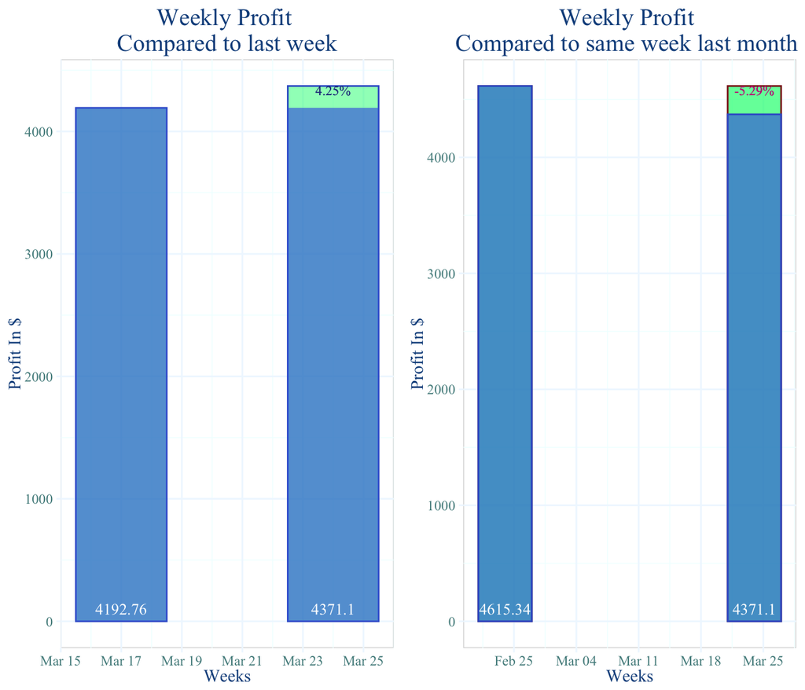

###### As figures above are showing, there was an increase in profit from last week, and a decrease compared to same week last month, marked in red.

[figure not shown]

End of weekly report,

### **OPPG 3**

De store endringene mellom ukesrapport og månedrapport, er at det vi legger fram rapporten i ShinyApp. Vi kom opp med diverse ting som vi ville vise i shiny underveis mens vi jobbet og så på figurer osv. Men vi begynte med å finne prosentvis endring i profit fra måneden før. Fordi vi tenker det kan være vesentlig for konsernledelsen å se nettopp dette. På samme primiss, tenker vi at kostnader, vil være noe som er intressant for de å vite. Fra tidligere har vi operert med Pizza og Veggie fra menyen, og vil vise antall produkter solgt innenfor disse. Dette kan være nyttig for å i fremtiden “luke ut” produkter som nødvendigvis ikke selger så bra. Nå var egentlig “oppskriften” klar da vi har gjort noe liknende i forrige oppgave. Legger ved koder osv her for å forklare framgangsmåten vår og hva/hvordan vi tenkte. Selve rapporten, ferdig produkt om du vil, med kodingen for dette og nærmere forklaring av shinyApp ligger som vedlegg.

```r
# Henter ut siste måneden
March_Rapport <- Utsalgsted_24 %>%
  ungroup() %>%
  filter_all(any_vars(grepl("2013-03",Date)))

# Velger ønsket kolonner
March_Rapport_24<- March_Rapport %>%
  select(Date,Sold,Profit,Description)

# Fjerner duplikasjons-verdier
March_Rapport_24 <- March_Rapport_24[!duplicated(March_Rapport_24), ]

# Grupperer by Date og summerer profit i mutate().
March_Rapport_24 <- March_Rapport_24 %>%
  group_by(Date) %>%
  mutate(Tot_Profit = sum(Profit))

# Summerer ukes-profittene til en samlet månedlig profit.
# Dette fordi vi ønsker å se den prosentvise endringen mellom månedene.
Total_Profit_March <- March_Rapport_24[!duplicated(March_Rapport_24$Tot_Profit), ]

Total_Profit_March <- Total_Profit_March %>%
  ungroup() %>%
  mutate(Tot_Revenue = sum(Tot_Profit))
#Setter verdien for Tot_Revenue for seg selv for senere å rbind() med måneden før.
Total_Profit_March <- Total_Profit_March[!duplicated(Total_Profit_March$Tot_Revenue), ]

#Gjør akkurat det samme for måneden før.
February_Rapport <- Utsalgsted_24 %>%
  ungroup() %>%
  filter_all(any_vars(grepl("2013-02",Date)))
#
February_Rapport_24<- February_Rapport %>%
  select(Date,Sold,Profit,Description)
#
February_Rapport_24 <- February_Rapport_24[!duplicated(February_Rapport_24), ]
#
February_Rapport_24 <- February_Rapport_24 %>%
  group_by(Date) %>%
  mutate(Tot_Profit = sum(Profit))
#
Total_Profit_February <- February_Rapport_24[!duplicated(February_Rapport_24$Tot_Profit), ]
#
Total_Profit_February <- Total_Profit_February %>%
  ungroup() %>%
  mutate(Tot_Revenue = sum(Tot_Profit))
#Setter verdien for Tot_Revenue for seg selv
Total_Profit_February <- Total_Profit_February[!duplicated(Total_Profit_February$Tot_Revenue), ]

# Regner ut endringen mellom månedene i posent.
Percent_Change_Month_Repport <- (Total_Profit_February$Tot_Revenue-Total_Profit_March$Tot_Revenue)/Total_Profit_February$Tot_Revenue*-1
Percent_Change_Month_Repport <- percent(Percent_Change_Month_Repport)
# Bruker rbind() til å binde månedene sammen
Compared_To_Laste_Month=rbind(March_Rapport_24, February_Rapport_24)
Compared_To_Laste_Month <- Compared_To_Laste_Month[!duplicated(Compared_To_Laste_Month$Tot_Profit),]
#
Rapport_Monthly_Change <- rbind(Total_Profit_March,Total_Profit_February)
# Her la vi med tanke på ønsket plot, forrige ukes profit inn i en ny df
Month_Of_February = Rapport_Monthly_Change$Tot_Revenue[2]
```

Når vi plottet figuren fulgte vi oppskriften fra ukes-rapporten. Etter å ha sett på figuren under, fikk vi en ide om at når vi koder dette inn i shinyApp, til måneds-rapporten, vil vi forsøke gjøre det slik at konsernledelsen kan endre hvilke måned de vil sammenligne endringen med. Altså, Mars og april, eller mars og januar, osv.

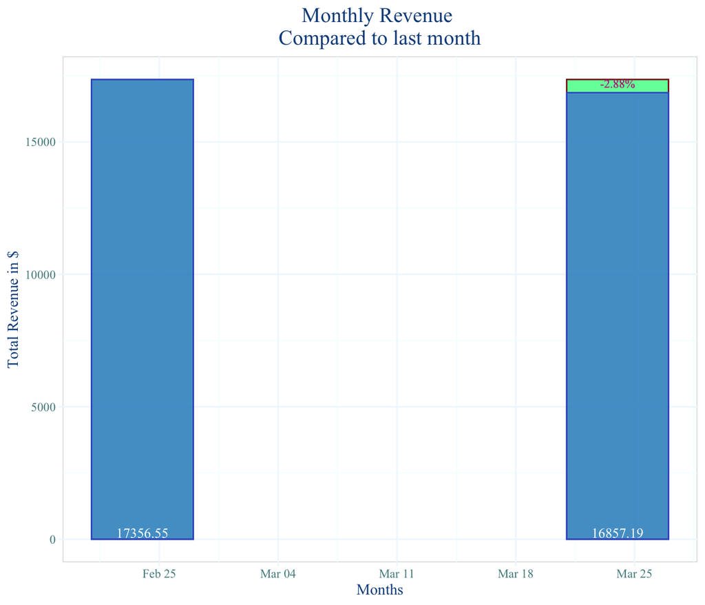

Deretter gikk vi videre for å se på Pizza og Veggie solgt. Informasjonen vi trengte da ligger klart i to datasett vi lagde ovenfor,*February_Rapport_24* og *March_Rapport_24*

```r
# Binder de sammen med rbind
Pizza_Sales <- rbind(February_Rapport_24,March_Rapport_24)

# Deretter hentes ut alt som har PIZZA i description med filter_all(any_vars(grepl()
Pizza_Sales <- Pizza_Sales %>%
  filter_all(any_vars(grepl("PIZZA",Description)))
```

Plottet var på alle måter uoversiktelig, vi forsøkte litt forskjellige plot. Tanken vår nå var at dersom vi klarte å lage et plot i shinyApp som hadde muligheten til å velge mellom alle pizza,- og veggie-rettene, ville det vært en fin måte konsernledelse kunne se utviklingen og salg av disse.

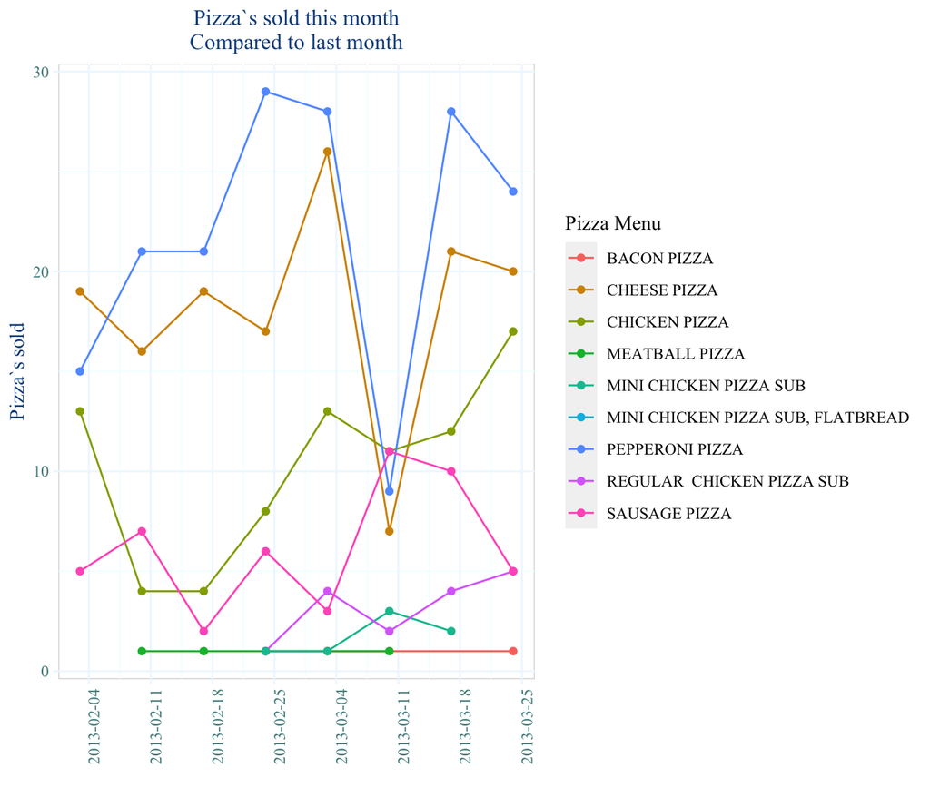

```r
# Gjorde det samme for vegetar rettene
Veggie_Sales <- rbind(February_Rapport_24,March_Rapport_24)

Veggie_Sales <- Veggie_Sales %>%
  filter_all(any_vars(grepl("VEGGIE",Description)))
```

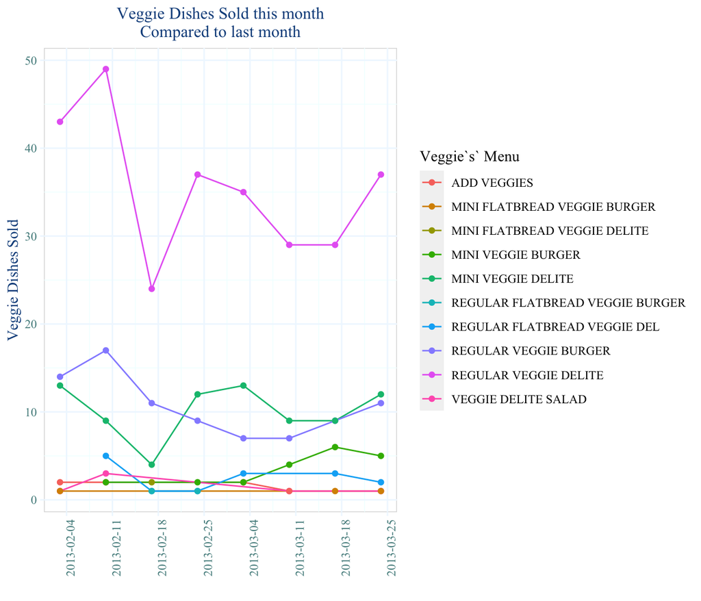

Videre nå henvises det til vedlegg(html). Der vises ytterligere koding, samt bilder av ferdig rapport.

### **OPPG 4**

Det vi tenkte å gjøre i denne oppgaven, selv om det ikke direkte var bedt om, var å legge fram en rapport basert på vår gjennomgang av datasettet med tanke på at konsernledelsen vurderte et nytt utsalgsted. Tanken bak det var at konsernledelsen da basert på vår analyse skulle kunne gjøre opp en mening om hvor det kunne vært lurt å åpne ett nytt utsalgsted. Det vi ville legge fram, og det vi tenkte kunne være vesentlig å ta en titt på var hvilken county som generelt hadde mest profit. Av de 5 counties som gjorde det best, så vi på kostnad for leie, konkurranse med andre, kriminalitet som hærverk, hvor de er lokalisert, drive through eller ikke drive through, populasjon og employmentrate med tanke på arbeidsledighet. I tillegg ville vi se på korrelasjonen om antall produkter solgt er væravhengig. Dette kunne jo være relevant og vite. Korrelasjonen tas i utgangspunkt av de to counties vi mener kan være best å åpne nytt utsalg sted i. Under ligger kodingen gjort for å finne nødvendige tall. Videre ble disse tallene skrevet inn i *table`s* som legges fram i den “rapporten” vi lager, der vi også gir forslag om en lovende plass for utsalgsted.

```r
# Under er all kodingen gjort for å finne tallene som vi videre skriver inn
# i table`s. Velger her å kun vise koding, og resultatet av alt i "rapporten" til slutt.

# Hvilke county gjør det generelt best?
# filterer ut hvert county å regner ut profit fra første måned, for alle "stores" i hver county.
Profit_For_Appleton<-Sandwich_df %>%
  ungroup() %>%
  dplyr::select(Date, Store_Num, Store_County, Profit) %>%
  filter(Store_County=="Appleton County" | Store_Num == "9") %>%
  filter(between(Date, as.Date("2012-04-01"), as.Date("2013-03-24")))%>%
  mutate(Appleton_Profit_9 = sum(Profit)) %>%
  dplyr::select(Appleton_Profit_9) %>%
  unique()
#
Profit_For_Power<-Sandwich_df %>%
  ungroup() %>%
  dplyr::select(Date, Store_Num, Store_County, Profit) %>%
  filter(Store_County=="Power County" | Store_Num == "2") %>%
  filter(between(Date, as.Date("2012-04-01"), as.Date("2013-03-24")))%>%
  mutate(Power_Profit_2 = sum(Profit)) %>%
  filter(Store_Num == "7") %>%
  mutate(Power_Profit_7 = sum(Profit)) %>%
  dplyr::select(Power_Profit_2,Power_Profit_7) %>%
  unique()
#
Profit_For_Power_7<-Weekly_Sales_Stores %>%
  dplyr::select(Date, Store_Num, Profit) %>%
  filter(Store_Num == "5") %>%
  filter(between(Date, as.Date("2012-04-01"), as.Date("2013-03-24")))%>%
  mutate(Power_Profit_5 = sum(Profit)) %>%
  dplyr::select(Power_Profit_5) %>%
  unique()
#
Profit_For_River<-Sandwich_df %>%
  ungroup() %>%
  dplyr::select(Date, Store_Num, Store_County, Profit) %>%
  filter(Store_County=="River County" | Store_Num == "11") %>%
  filter(between(Date, as.Date("2012-04-01"), as.Date("2013-03-24")))%>%
  mutate(River_Profit_11 = sum(Profit)) %>%
  filter(Store_Num == "24") %>%
  mutate(River_Profit_24 = sum(Profit)) %>%
  dplyr::select(River_Profit_11,River_Profit_24) %>%
  unique()
#
Profit_For_Farm<-Sandwich_df %>%
  ungroup() %>%
  dplyr::select(Date, Store_Num, Store_County, Profit) %>%
  filter(Store_County=="Farm County" | Store_Num == "19") %>%
  filter(between(Date, as.Date("2012-04-01"), as.Date("2013-03-24")))%>%
  mutate(Farm_Profit_19 = sum(Profit)) %>%
  filter(Store_Num == "23") %>%
  mutate(Farm_Profit_23 = sum(Profit)) %>%
  dplyr::select(Farm_Profit_19,Farm_Profit_23) %>%
  unique()
#
Profit_For_Lake<-Sandwich_df %>%
  ungroup() %>%
  dplyr::select(Date, Store_Num, Store_County, Profit) %>%
  filter(Store_County=="Lake County" | Store_Num == "16") %>%
  filter(between(Date, as.Date("2012-04-01"), as.Date("2013-03-24")))%>%
  mutate(Lake_Profit_16 = sum(Profit)) %>%
  dplyr::select(Lake_Profit_16) %>%
  unique()
#
Profit_For_Rail<-Sandwich_df %>%
  ungroup() %>%
  dplyr::select(Date, Store_Num, Store_County, Profit) %>%
  filter(Store_County=="Rail County" | Store_Num == "14") %>%
  filter(between(Date, as.Date("2012-04-01"), as.Date("2013-03-24")))%>%
  mutate(Rail_Profit_14 = sum(Profit)) %>%
  dplyr::select(Rail_Profit_14) %>%
  unique()
# Bruker nå cbind for å binde de sammen til en df
Profit_For_County <- cbind(Profit_For_Appleton,
                           Profit_For_Power,
                           Profit_For_Power_7,
                           Profit_For_River,
                           Profit_For_Farm,
                           Profit_For_Lake,
                           Profit_For_Rail)

# Henter ut de som har profit på over 350 000. Står igjen med
# Appleton,River,Farm,Lake,Power County.
Leading_Stores<-Profit_For_County[colSums(Profit_For_County > 350000) > 0]
```

```r
# Av disse som har gjort det best samler vi videre data,
# først konkurransen
Store_Competition <- Sandwich_df %>%
  ungroup() %>%
  dplyr::select(Store_County, Store_Num, Store_Competition_Fastfood, Store_Competition_Otherfood) %>%
  filter_all(any_vars(grepl("Appleton|River|Farm|Lake|Power", Store_County))) %>%
  unique()

# Så finner vi kostnad for leie
Annual_Rent <- Sandwich_df %>%
  ungroup() %>%
  dplyr::select(Store_County,Store_Num,Annual_Rent_Estimate) %>%
  filter_all(any_vars(grepl("Appleton|River|Farm|Lake|Power", Store_County))) %>%
  unique()
Annual_Rent <- Annual_Rent[order(as.numeric(as.character(Annual_Rent$Annual_Rent_Estimate))),]

# Finner ut om det er mye kriminalitet, hærverk på bygninger.
Criminality <- Sandwich_df %>%
  ungroup() %>%
  dplyr::select(Store_County,Store_Num, County_Property_Crimes) %>%
  filter_all(any_vars(grepl("Appleton|River|Farm|Lake|Power", Store_County))) %>%
  unique()

# Finner ut hvor hvilke county som har flest folk og høy arbeidsledighet
People_And_Employment <- Sandwich_df %>%
  ungroup() %>%
  dplyr::select(Store_County,Store_Num, County_Total_Census_Pop, County_Unemployment_Rate) %>%
  filter_all(any_vars(grepl("Appleton|River|Farm|Lake|Power", Store_County))) %>%
  unique()
# Som rapporten senere vil vise, ender vi opp med enten River eller Farm county.
# På grunnlag av utsalgsted 11(River County), og 19(Farm County)
```

```r
####################################################################################
# Her begynner kodingen for å se på om antall solgte produkter er væravhengig.
# Da tar vi for oss utsalgstedene 11 og 19 for å se om de solgte best dersom
# det var godt vær basert på siste året. Tanken var at den County med været som solgte
# best (om det skulle vise seg å være en korrelasjon), kunne være et County å anbefale.

# Dette gjøres i to deler, her er første del.
# Henter ut nødvendig data fra River og Farm.
# Da været baserer seg på "Bad_Weather_week" = yes/no, altså uke, var det nødvendig
# å regne ut antall solgte produkter i kolonnen "Sold" for hver uke.
# Begynte med River County, 11.
Sales_Vs_Weather_11 <- Sandwich_df %>%
  ungroup() %>%
  dplyr::select(Date,Store_County, Store_Num, Sold, Weather_Bad_Weather_Week) %>%
  filter(Store_County =="River County") %>%
  filter(Store_Num =="11") %>%
  group_by(Store_Num)

#Bruker aggragate(), der cut() sier hvor mange dager som er ønskelig å sum()
output11<-aggregate(Sold ~ cut(Date, "7 days"), Sales_Vs_Weather_11, sum)

# Gjør om navn på kolonnene
names(output11)[1]="Date"
names(output11)[2]="Sold_11"

# Gjør så akkurat det samme for Farm County, 19
Sales_Vs_Weather_19 <- Sandwich_df %>%
  ungroup() %>%
  dplyr::select(Date,Store_County, Store_Num, Sold, Weather_Bad_Weather_Week) %>%
  filter(Store_County =="Farm County") %>%
  filter(Store_Num =="19") %>%
  group_by(Store_Num)
#
output19 <- aggregate(Sold ~ cut(Date, "7 days"), Sales_Vs_Weather_19, sum)
#
names(output19)[1]="Date"
names(output19)[2]="Sold_19"

# Bruker left_join her for å joine by = "Weeks"
output11_19 <- output11 %>%
  dplyr::left_join(output19, by = "Date")
```

```r
# Her begynner andre del.
# Så var det å telle/hente gode og dårlige vær uker,
# Først River, 11
Bad_Weather_11 <- Sales_Vs_Weather_11 %>%
  dplyr::select(Date, Store_County, Store_Num, Weather_Bad_Weather_Week)

# Fjerner duplikasjoner
Bad_Weather_11_1 <- Bad_Weather_11[!duplicated(Bad_Weather_11$Date), ]

# Velger kolloner
Bad_Weather_11_11 <- Bad_Weather_11_1 %>%
  dplyr::select(Store_Num, Weather_Bad_Weather_Week)

# Gjør det samme for Farm, 19
Bad_Weather_19 <- Sales_Vs_Weather_19 %>%
  dplyr::select(Date, Store_County, Store_Num, Weather_Bad_Weather_Week)
#
Bad_Weather_19_1 <- Bad_Weather_19[!duplicated(Bad_Weather_19$Date), ]
#
Bad_Weather_19_19 <- Bad_Weather_19_1 %>%
  dplyr::select(Store_Num, Weather_Bad_Weather_Week)
```

```r
# Bruker cbind for å binde disse sammen igjen.
Bad_Weather_11_19<- dplyr::bind_cols(Bad_Weather_11_11, Bad_Weather_19_19)

# Gjør så om på kollonne navn for å vite hva som er hva.
# Endret til good_weather fordi vi tenkte det kanskje solgte best på
# godværsdager.
names(Bad_Weather_11_19)[1]="River"
names(Bad_Weather_11_19)[2]="Good_Weather_11"
names(Bad_Weather_11_19)[3]="Farm"
names(Bad_Weather_11_19)[4]="Good_Weather_19"

Bad_Weather_11_19
```

```r
#Binder så til slutt den første delen og andre delen.
Sales_And_Weather_Comp <- dplyr::bind_cols(output11_19, Bad_Weather_11_19)

# Fordi vi endret til good_weather, var det også nødvendig å endre
# at no = yes, og yes = no.
Sales_And_Weather_Comp$Good_Weather_11[Sales_And_Weather_Comp$Good_Weather_11 == "No"] <- "YES"
Sales_And_Weather_Comp$Good_Weather_11[Sales_And_Weather_Comp$Good_Weather_11 == "Yes"] <- "NO"
Sales_And_Weather_Comp$Good_Weather_19[Sales_And_Weather_Comp$Good_Weather_19 == "No"] <- "YES"
Sales_And_Weather_Comp$Good_Weather_19[Sales_And_Weather_Comp$Good_Weather_19 == "Yes"] <- "NO"

Sales_And_Weather_Comp[is.na(Sales_And_Weather_Comp)]<-0

Sales_And_Weather_Comp
# Kjørte en lm utregning her for å se korrelasjon,River County
lm_11<-lm(Sold_11~ Good_Weather_11, data = Sales_And_Weather_Comp)
#Koeff. Intercept, 2601.857, GoodWeatherYES, -355.09
#Dette gir os svaret på at salget går ned dersom ukeværet er å regne som fint.
lm_19<-lm(Sold_19~ Good_Weather_19, data = Sales_And_Weather_Comp)
```

Til plottet var det ønskelig med samme tema som vi har hatt gjennom det hele. Men vi ville ha River og Farm County side om side for å vise de hver for seg. Det vi gikk for da, som var veldig enkelt, var å navngi plottene hver for seg, for deretter legge de samlet med en delt legend. Dette fikk vi til med en pakke kalt ggpubr. Den pakken har en funksjon kalt ggarrange() som gjorde jobben lett. Her kunne vi sikkert også brukt en form for facet.grid. Viser koden til plottet her, men selve plottet i “rapporten” lengre ned.

```r
p1<- ggplot(Sales_And_Weather_Comp, aes(Date, Sold_11, colour = Good_Weather_11))
p1<-p1+geom_jitter()+
  scale_color_manual(values = alpha(c("NO"="springgreen","YES"="royalblue"),.85))+
  labs(x = "Weeks",
       y = "Menu Items Sold",
       title = "River County",
       color = "River & Farm County \nWeather Good?")+
  theme(text=element_text(family = "Times New Roman"),
        plot.title = element_text(colour = "dodgerblue4", hjust = 0.5, size = 12),
        axis.title.y = element_text(colour = "dodgerblue4"),
        axis.title.x = element_text(colour = "dodgerblue4"),
        axis.ticks = element_line(colour = "aliceblue"),
        axis.text.x = element_text(angle = 90),
        axis.text.x.bottom = element_blank(),
        axis.text.y.left = element_text(colour = "darkslategray4"),
        panel.background = element_rect(fill = "white", colour = "grey85"),
        panel.grid.major = element_line(colour = "azure1"),
        panel.grid.minor = element_line(colour = "azure"))
  p2<-ggplot(Sales_And_Weather_Comp, aes(Date, Sold_19, colour = Good_Weather_19))
  p2<-p2+geom_jitter()+
    scale_color_manual(values = alpha(c("NO"="springgreen","YES"="royalblue"),.85))+
    labs(x = "Weeks",
         y = "",
         title = "Farm County",
         color = "River & Farm County \nWeather Good?")+
    theme(text=element_text(family = "Times New Roman"),
          plot.title = element_text(colour = "dodgerblue4", hjust = 0.5, size = 12),
          axis.title.y = element_text(colour = "dodgerblue4"),
          axis.title.x = element_text(colour = "dodgerblue4"),
          axis.ticks = element_line(colour = "aliceblue"),
          axis.text.x = element_text(angle = 90),
          axis.text.x.bottom = element_blank(),
          axis.text.y.left = element_text(colour = "darkslategray4"),
          panel.background = element_rect(fill = "white", colour = "grey85"),
          panel.grid.major = element_line(colour = "azure1"),
          panel.grid.minor = element_line(colour = "azure"))
ggarrange(p1,p2, ncol= 2, nrow=1, common.legend= TRUE, legend = "bottom")
```

#### **Raport**

We at ACME Analytics have collected what we believe are necassary information needed in order to open a new store. With our data collectivly, you will be able to determine where a potentially profitable store could be opened for business.

##### Total revenue for stores havin performed the best this year

| Tot. Revenue Power County | Tot. Revenue Lake County | Tot. Revenue Farm County | Tot. Revenue River County |
| --- | --- | --- | --- |
| $1 238373 | $374081. | $711731.2 | $439350 |
| $395206 |  |  |  |

###### Here we can see Power County having performed the best. Followed up by Farm,- and River County. The continuation of this report will be based on these Counties.

##### Store Competition

| County | Competition Fastfood | Competition Other Food | Tot. Competition |
| --- | --- | --- | --- |
| Power County | 15 | 31 | 46 |
| Lake County | 8 | 3 | 11 |
| Farm County | 8 | 38 | 46 |
| River County | 10 | 31 | 41 |

###### The least competition is to find in Lake County. Most competition are found in Power,- and Farm County.

##### Rent

| County | Annual Cost of Rent |
| --- | --- |
| Power County | $45000-$65000 |
| Lake County | $40000 |
| Farm County | $35000 |
| River County | $15000-$50000 |

###### In order to compete against the stores having performed the best, the annual cost of rent is seen above.

##### Property Crime

| County | Number of Property Crimes |
| --- | --- |
| Power County | 7507 |
| Lake County | 5288 |
| Farm County | Nothing to report |
| River County | 953 |

###### Avoiding crime, and property crime will decrease unnecassary cost of repairs, therefore in the long run, we find that choosing a low crime rate county is preferable.

##### Location and Drive-Through

| County | Location | Drive Through | Near School |
| --- | --- | --- | --- |
| Power County | Free Standing | Yes | Yes |
| Lake County | Strip Mall | Yes | Yes |
| Farm County | Strip Mall | No | Yes |
| River County | Strip Mall | No | Yes |

###### Based on these counties having performed the best, it could be wise to take a look at where they are located. We can see that a store in a strip mall near a school could be preferable.

##### Population and Unemployment Rate

| County | Total Population | Unemploymentrate |
| --- | --- | --- |
| Power County | 246 977 | 10.6 % |
| Lake County | 91 723 | 9.5 % |
| Farm County | 76 820 | 9.1 % |
| River County | 59 404 | 7.5 % |

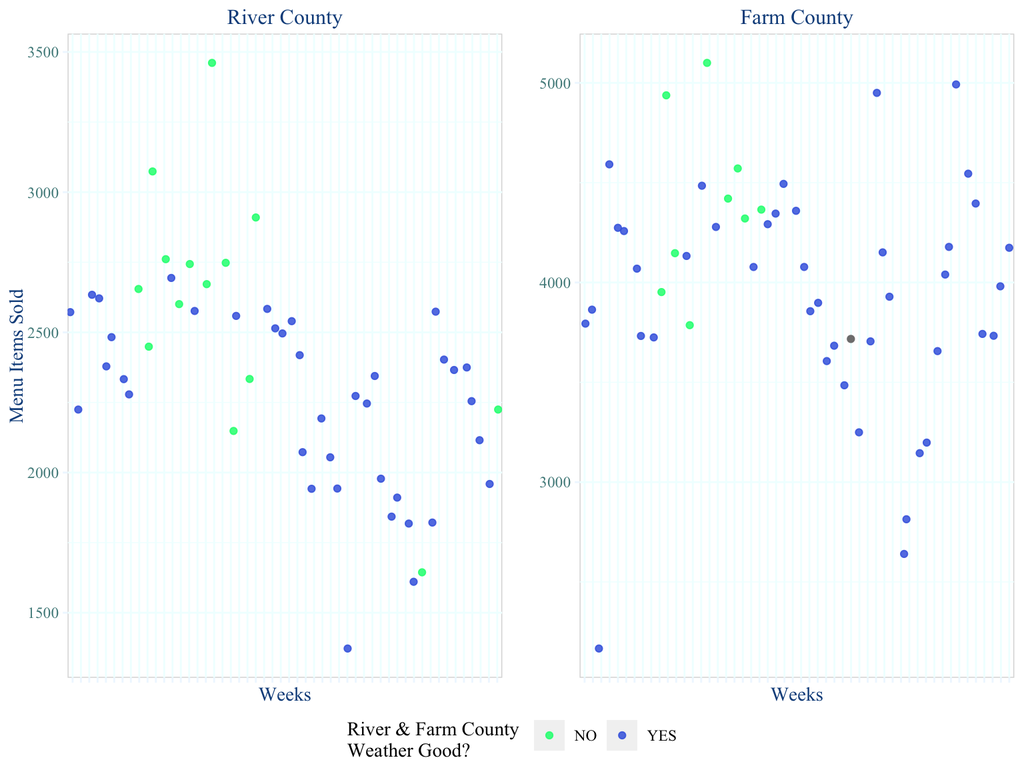

###### Here we can see River County on the left and Farm County on the right. Take a look at Menu items sold and the green points for both counties. As you might be able to see, during bad weather weeks, there is an increase in the avarage total of items sold. Farm County is selling most items overall, but are having less bad weather weeks. River City are selling less items, but have got more bad weather weeks. In both counties the best sales weeks was weeks where the weather conditions were considered bad.

We at ACME Analytics hope you found this information helpful for making your decision.

End of report,